# Forecast virus result using deep learning

This project use R to create pipelines for periodic analysis of a medical data, using classification techniques including decision tree, naive Bayes, support vector machine, and artificial neural networks.

# Overview

Data mining methods are widely used to identify patterns, rules or associations, and to predict outcomes among numbers of data. The purpose of this project is to build a pipeline for periodic analysis of employee medical data and choose the best classification technique. The employee medical data is randomly generated with 6,781 observations. The process includes merging the data, cleaning the data, processing classification technique, and generating plots. The decision tree was chosen for the final model due to its overall performance. The model is also easy to explain and compare to other classification models.

# Data

The employee medical data contains data from 6,781 employees in total which consists of 5,424 training data observations and 1,357 test data observations. The data are from 2 sources, A and B, which consist of 6 variables and 8 variables, respectively. All files have an ID for each employee which uniquely identifies the employee. Thus, employee ID 123 in the A file is the same employee as ID 123 in the B file.

# Data cleaning and preparation

This analysis utilizes the R markdown program along with multiple other R packages to do the model analysis. The following are R packages that have been used in this analysis: ggplot2 and dplyr, accompanied with a collection of R packages designed for data mining such as rpart, rpart.plot, e1071, neuralnet, and so on.

```r
# read data into R
dataTrainA=read.table("data/virus_test_deep_learning/dataTrainA.txt", header=TRUE)
dataTrainB=read.table("data/virus_test_deep_learning/dataTrainB.txt", header=TRUE)
dataTestA=read.table("data/virus_test_deep_learning/dataTestA.txt", header=TRUE)
dataTestB=read.table("data/virus_test_deep_learning/dataTestB.txt", header=TRUE)

# Merge train dataset A and B by id and atRisk
traindata=merge(dataTrainA, dataTrainB, by=c("id","atRisk"))

# Merge test dataset A and B
testdata=merge(dataTestA, dataTestB, by=c("id","atRisk"))
```

The train data has 8 missing values, while the test data has no missing value.

```r
table(is.na(traindata))
```

```
FALSE  TRUE
65080     8
```

```r
table(is.na(testdata))
```

```
FALSE
16284
```

```r
#functions to filter noises and missing
myCleanFunction <- function(datatoclean){
                    datatoclean%>%filter(between(temp,90,106),
                      between(bpSys,97,150),
                      between(vo2,10,70),
                      between(throat,80,120),
                      between(atRisk,0,1),
                      between(headA,0,9),
                      between(bodyA,0,9),
                      between(cough,0,1),
                      between(runny,0,1),
                      between(nausea,0,1),
                      between(diarrhea,0,1)
                    )}

#function to identify outliers
outliers <- function(data,c){boxplot(data[,c], plot=FALSE)$out}
```

**Train and test data after cleaning** **Train data**

```r
summary(tr)
```

```
       id           atRisk            temp            bpSys
 Min.   :   0   Min.   :0.0000   Min.   : 96.18   Min.   :103.0
 1st Qu.:1688   1st Qu.:0.0000   1st Qu.: 97.77   1st Qu.:119.0
 Median :3360   Median :0.0000   Median : 98.16   Median :124.0
 Mean   :3383   Mean   :0.4521   Mean   : 98.40   Mean   :124.4
 3rd Qu.:5091   3rd Qu.:1.0000   3rd Qu.: 98.80   3rd Qu.:130.0
 Max.   :6780   Max.   :1.0000   Max.   :100.63   Max.   :146.0
      vo2            throat          headA           bodyA
 Min.   :22.00   Min.   : 88.0   Min.   :0.000   Min.   :1.000
 1st Qu.:34.00   1st Qu.: 97.0   1st Qu.:3.000   1st Qu.:4.000
 Median :39.00   Median :100.0   Median :3.000   Median :4.000
 Mean   :38.04   Mean   :100.1   Mean   :3.451   Mean   :4.017
 3rd Qu.:42.00   3rd Qu.:103.0   3rd Qu.:4.000   3rd Qu.:4.000
 Max.   :54.00   Max.   :112.0   Max.   :8.000   Max.   :7.000
     cough            runny            nausea          diarrhea
 Min.   :0.0000   Min.   :0.0000   Min.   :0.0000   Min.   :0.0000
 1st Qu.:0.0000   1st Qu.:0.0000   1st Qu.:0.0000   1st Qu.:0.0000
 Median :0.0000   Median :0.0000   Median :0.0000   Median :0.0000
 Mean   :0.3258   Mean   :0.1983   Mean   :0.2403   Mean   :0.1022
 3rd Qu.:1.0000   3rd Qu.:0.0000   3rd Qu.:0.0000   3rd Qu.:0.0000
 Max.   :1.0000   Max.   :1.0000   Max.   :1.0000   Max.   :1.0000
```

**Test data**

```r
summary(te)
```

```
       id           atRisk            temp            bpSys
 Min.   :   2   Min.   :0.0000   Min.   : 96.35   Min.   : 98.0
 1st Qu.:1786   1st Qu.:0.0000   1st Qu.: 97.79   1st Qu.:119.0
 Median :3533   Median :0.0000   Median : 98.21   Median :124.0
 Mean   :3447   Mean   :0.4584   Mean   : 98.51   Mean   :124.4
 3rd Qu.:5087   3rd Qu.:1.0000   3rd Qu.: 99.12   3rd Qu.:130.0
 Max.   :6770   Max.   :1.0000   Max.   :101.58   Max.   :147.0
      vo2            throat           headA           bodyA
 Min.   :18.00   Min.   : 86.00   Min.   :0.000   Min.   :2.000
 1st Qu.:33.00   1st Qu.: 97.00   1st Qu.:3.000   1st Qu.:4.000
 Median :38.00   Median :100.00   Median :3.000   Median :4.000
 Mean   :37.48   Mean   : 99.73   Mean   :3.408   Mean   :4.025
 3rd Qu.:42.00   3rd Qu.:103.00   3rd Qu.:4.000   3rd Qu.:4.000
 Max.   :55.00   Max.   :114.00   Max.   :8.000   Max.   :7.000
     cough          runny            nausea          diarrhea
 Min.   :0.00   Min.   :0.0000   Min.   :0.0000   Min.   :0.00000
 1st Qu.:0.00   1st Qu.:0.0000   1st Qu.:0.0000   1st Qu.:0.00000
 Median :0.00   Median :0.0000   Median :0.0000   Median :0.00000
 Mean   :0.35   Mean   :0.1945   Mean   :0.2402   Mean   :0.09359
 3rd Qu.:1.00   3rd Qu.:0.0000   3rd Qu.:0.0000   3rd Qu.:0.00000
 Max.   :1.00   Max.   :1.0000   Max.   :1.0000   Max.   :1.00000
```

# Exploratory Data Analysis

Table 1: Table representing variable summary (n=5165).

| Variable | Type | Median | Mean | SD | Min | Max |
| --- | --- | --- | --- | --- | --- | --- |
| temp | Numeric | 98.16 | 98.4 | 0.91 | 96.18 | 100.63 |
| bpSys | Numeric | 124 | 124.4 | 8.05 | 103 | 146 |
| vo2 | Numeric | 39 | 38.04 | 5.97 | 22 | 54 |
| throat | Numeric | 100 | 100.1 | 4.47 | 88 | 112 |
| headA | Factor | 3 | 3.45 | 1.07 | 0 | 8 |
| bodyA | Factor | 4 | 4.02 | 0.67 | 1 | 7 |
| cough | Factor | 0 (n=3482), 1 (n=1683) |  |  |  |  |
| runny | Factor | 0 (n=4141), 1 (n=1024) |  |  |  |  |
| nausea | Factor | 0 (n=3924), 1 (n=1241) |  |  |  |  |
| diarrhea | Factor | 0 (n=4637), 1 (n=528) |  |  |  |  |
| atRisk | Factor | 0 (n=2830), 1 (n=2335) |  |  |  |  |

## Histogram

```r
hist2 = function(df, var,b){ggplot(df, aes(x=var, color=atRisk))+
    geom_histogram(fill="white", alpha=0.5, position="identity",binwidth = b)+
    theme_minimal()+
    ggtitle("Histogram of employee medical data")}
```

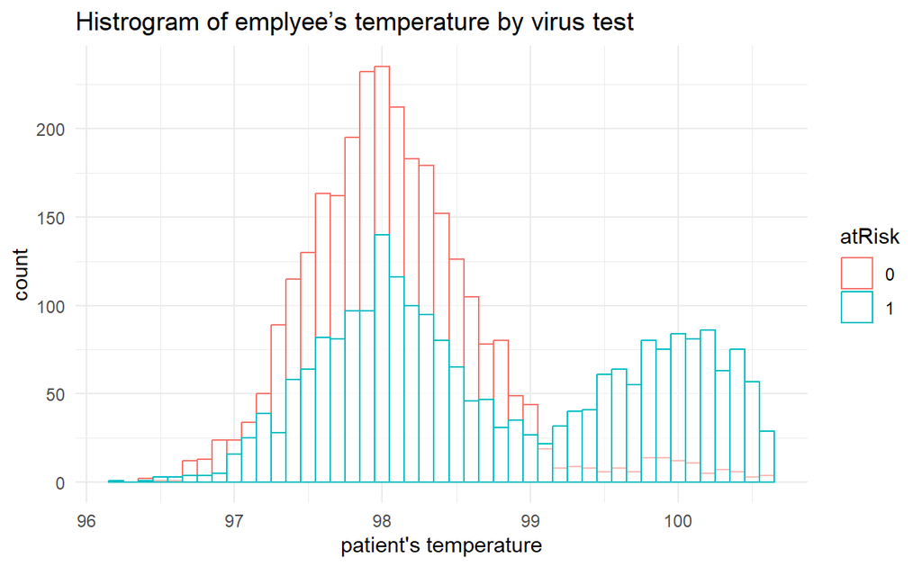

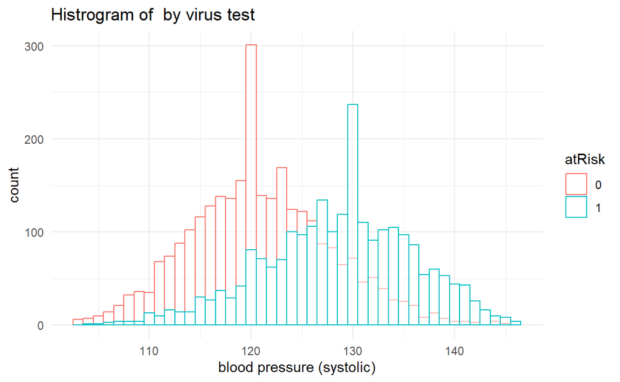

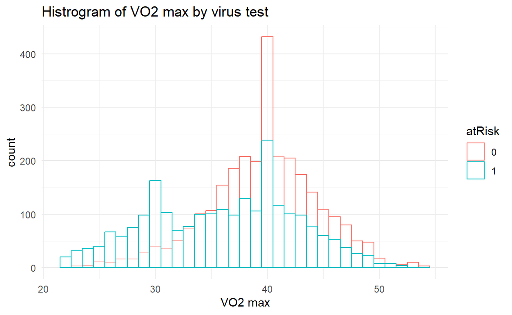

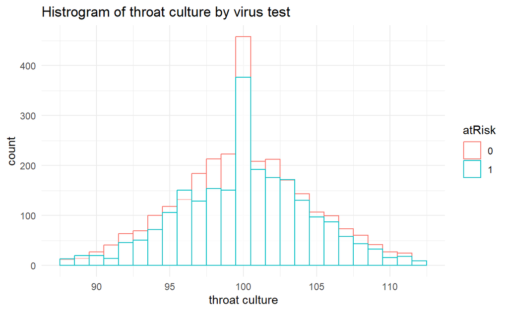

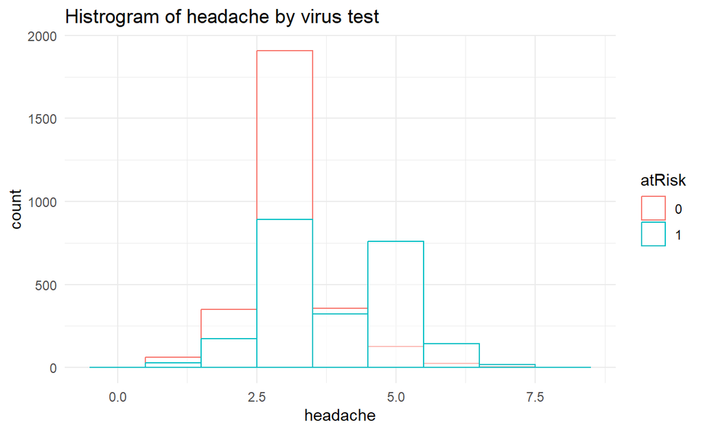

```r
hist2(md,md[,3],0.1)+xlab("patient's temperature")+ggtitle("Histrogram of emplyee’s temperature by virus test")
hist2(md,md[,4],1)+xlab("blood pressure (systolic)")+ggtitle("Histrogram of  by virus test")
hist2(md,md[,5],1)+xlab("VO2 max")+ggtitle("Histrogram of VO2 max by virus test")
hist2(md,md[,6],1)+xlab("throat culture")+ggtitle("Histrogram of throat culture by virus test")
hist2(md,md[,7],1)+xlab("headache")+ggtitle("Histrogram of headache by virus test")
```

## Boxplot

```r
boxplotFunction=function(dat,c,var, title, x, y){
  boxplot(dat[,c]~var, data=dat, main=title,
          xlab=x, ylab=y)}
```

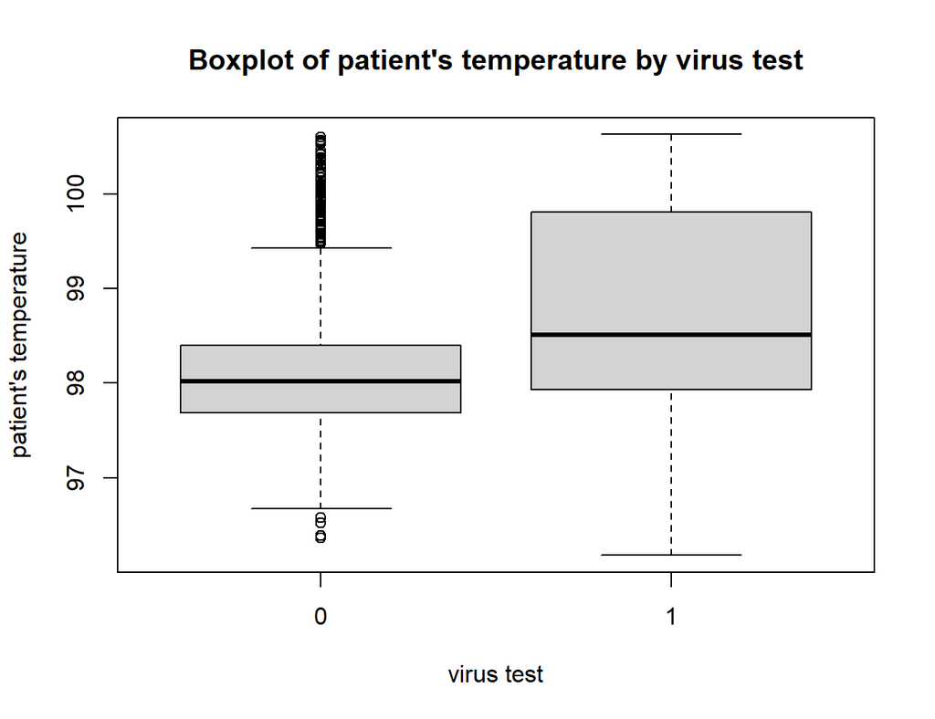

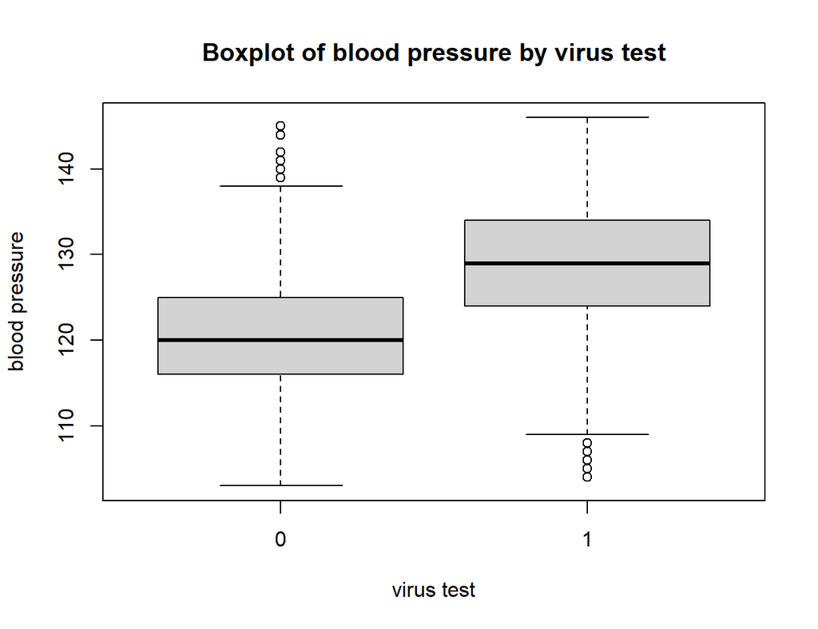

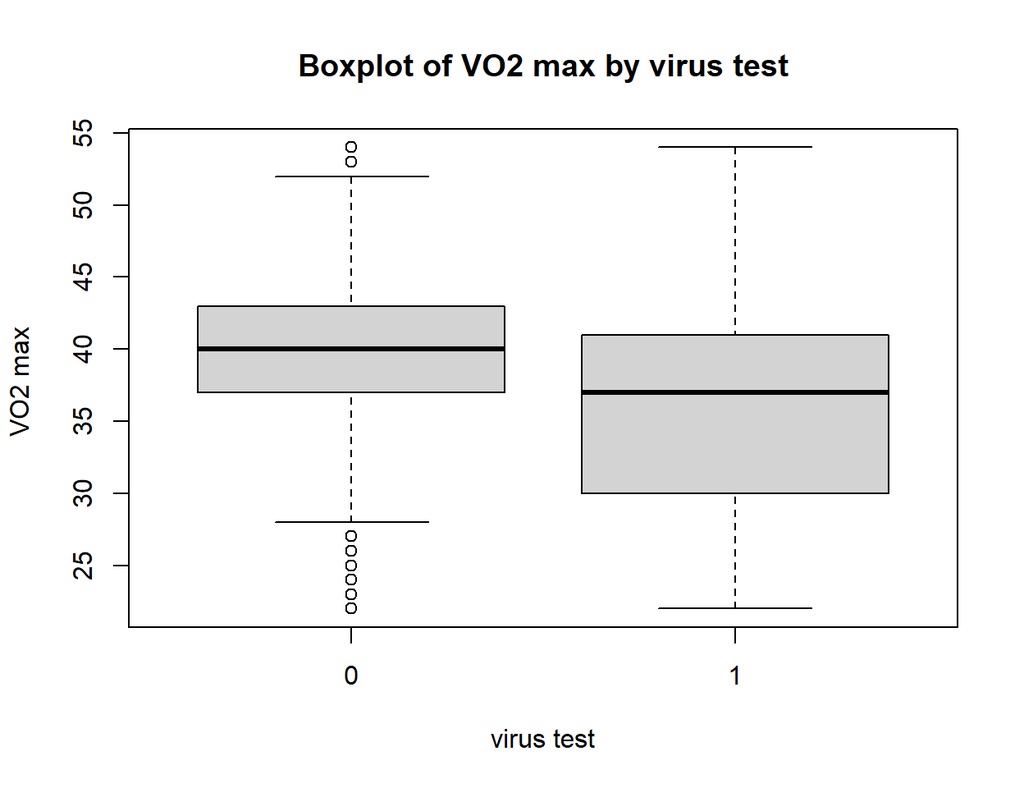

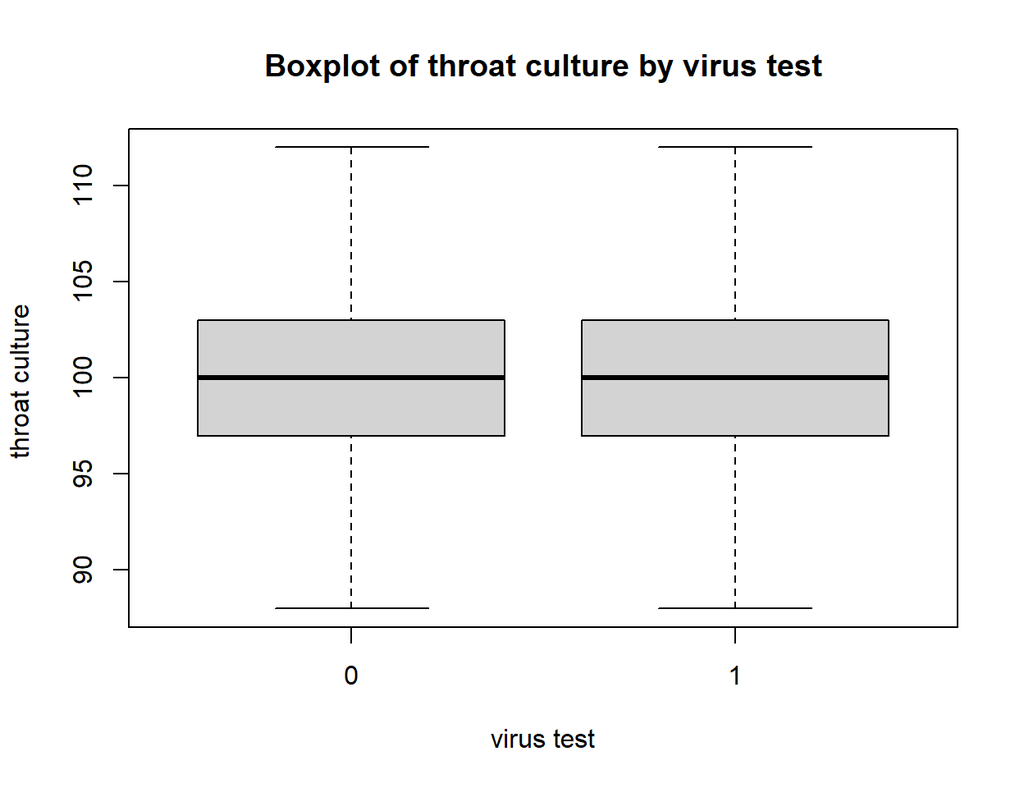

```r
boxplotFunction(tr,3,tr$atRisk,"Boxplot of patient's temperature by virus test", "virus test", "patient's temperature")
boxplotFunction(tr,4,tr$atRisk,"Boxplot of blood pressure by virus test", "virus test", "blood pressure")
boxplotFunction(tr,5,tr$atRisk,"Boxplot of VO2 max by virus test", "virus test", "VO2 max ")
boxplotFunction(tr,6,tr$atRisk,"Boxplot of throat culture by virus test", "virus test", "throat culture ")
```